# FINAL PROJECT 1: LINEAR REGRESSION

LUKMAN PRASETYO NUGROHO (PYTN-KS09-004)  
NATHANIA GUNAWAN (PYTN-KS09-006)

## A. Perkenalan

Dataset yang kami gunakan yaitu Uber and Lyft Dataset Boston, MA yang berisi histori data perjalanan Uber dan Lyft di Boston. Analisis kami bertujuan untuk memprediksi dan membandingkan, Bagaimana cab type, name, surge multiplier, dan distance mempengaruhi harga Uber dan Lyft.

Dataset yang kami gunakan berasal dari terdiri dari https://www.kaggle.com/datasets/brllrb/uber-and-lyft-dataset-boston-ma 57 kolom dan 693.071 data , yakni:

id, timestamp, hour, day, month, datetime, timezone, source, destination, cab_type, product_id, name, price, distance, surge_multiplier, latitude, longitude, temperature, apparentTemperature, short_summary, long_summary, precipIntensity, precipProbability, humidity, windSpeed, windGust, windGustTime, visibility, temperatureHigh, temperatureHighTime, temperatureLow, temperatureLowTime, apparentTemperatureHigh, apparentTemperatureHighTime, apparentTemperatureLow, apparentTemperatureLowTime, icon, dewPoint, pressure, windBearing, cloudCover, uvIndex, visibility.1, ozone, sunriseTime, sunsetTime, moonPhase, precipIntensityMax, uvIndexTime, temperatureMin, temperatureMinTime, temperatureMax, temperatureMaxTime, apparentTemperatureMin, apparentTemperatureMinTime, apparentTemperatureMax, dan apparentTemperatureMaxTime

## B.Import Package

```python
import pandas as pd
import numpy as np
import matplotlib.pyplot as plt
from sklearn.linear_model import LinearRegression
from sklearn.model_selection import train_test_split
from statsmodels.stats.outliers_influence import variance_inflation_factor
import seaborn as sns
%matplotlib inline
from sklearn.preprocessing import StandardScaler
from sklearn.preprocessing import OneHotEncoder
import sys
from statsmodels.stats.diagnostic import normal_ad

if not sys.warnoptions:
    import warnings
    warnings.simplefilter("ignore")
```

## C. Data Loading

### Read Dataframe

```python
from google.colab import drive
drive.mount('/content/drive/')
```

```python
%cd drive/MyDrive/dataset/uber-and-lyft-dataset-boston-ma
```

```
/content/drive/MyDrive/dataset/uber-and-lyft-dataset-boston-ma
```

```python
df = pd.read_csv('rideshare_kaggle.csv')
df
```

|  | id | timestamp | hour | day | month | datetime | timezone | source | destination | cab_type | ... | precipIntensityMax | uvIndexTime | temperatureMin | temperatureMinTime | temperatureMax | temperatureMaxTime | apparentTemperatureMin | apparentTemperatureMinTime | apparentTemperatureMax | apparentTemperatureMaxTime |
| --- | --- | --- | --- | --- | --- | --- | --- | --- | --- | --- | --- | --- | --- | --- | --- | --- | --- | --- | --- | --- | --- |
| 0 | 424553bb-7174-41ea-aeb4-fe06d4f4b9d7 | 1.544953e+09 | 9 | 16 | 12 | 2018-12-16 09:30:07 | America/New_York | Haymarket Square | North Station | Lyft | ... | 0.1276 | 1544979600 | 39.89 | 1545012000 | 43.68 | 1544968800 | 33.73 | 1545012000 | 38.07 | 1544958000 |
| 1 | 4bd23055-6827-41c6-b23b-3c491f24e74d | 1.543284e+09 | 2 | 27 | 11 | 2018-11-27 02:00:23 | America/New_York | Haymarket Square | North Station | Lyft | ... | 0.1300 | 1543251600 | 40.49 | 1543233600 | 47.30 | 1543251600 | 36.20 | 1543291200 | 43.92 | 1543251600 |
| 2 | 981a3613-77af-4620-a42a-0c0866077d1e | 1.543367e+09 | 1 | 28 | 11 | 2018-11-28 01:00:22 | America/New_York | Haymarket Square | North Station | Lyft | ... | 0.1064 | 1543338000 | 35.36 | 1543377600 | 47.55 | 1543320000 | 31.04 | 1543377600 | 44.12 | 1543320000 |
| 3 | c2d88af2-d278-4bfd-a8d0-29ca77cc5512 | 1.543554e+09 | 4 | 30 | 11 | 2018-11-30 04:53:02 | America/New_York | Haymarket Square | North Station | Lyft | ... | 0.0000 | 1543507200 | 34.67 | 1543550400 | 45.03 | 1543510800 | 30.30 | 1543550400 | 38.53 | 1543510800 |
| 4 | e0126e1f-8ca9-4f2e-82b3-50505a09db9a | 1.543463e+09 | 3 | 29 | 11 | 2018-11-29 03:49:20 | America/New_York | Haymarket Square | North Station | Lyft | ... | 0.0001 | 1543420800 | 33.10 | 1543402800 | 42.18 | 1543420800 | 29.11 | 1543392000 | 35.75 | 1543420800 |
| ... | ... | ... | ... | ... | ... | ... | ... | ... | ... | ... | ... | ... | ... | ... | ... | ... | ... | ... | ... | ... | ... |
| 693066 | 616d3611-1820-450a-9845-a9ff304a4842 | 1.543708e+09 | 23 | 1 | 12 | 2018-12-01 23:53:05 | America/New_York | West End | North End | Uber | ... | 0.0000 | 1543683600 | 31.42 | 1543658400 | 44.76 | 1543690800 | 27.77 | 1543658400 | 44.09 | 1543690800 |
| 693067 | 633a3fc3-1f86-4b9e-9d48-2b7132112341 | 1.543708e+09 | 23 | 1 | 12 | 2018-12-01 23:53:05 | America/New_York | West End | North End | Uber | ... | 0.0000 | 1543683600 | 31.42 | 1543658400 | 44.76 | 1543690800 | 27.77 | 1543658400 | 44.09 | 1543690800 |
| 693068 | 64d451d0-639f-47a4-9b7c-6fd92fbd264f | 1.543708e+09 | 23 | 1 | 12 | 2018-12-01 23:53:05 | America/New_York | West End | North End | Uber | ... | 0.0000 | 1543683600 | 31.42 | 1543658400 | 44.76 | 1543690800 | 27.77 | 1543658400 | 44.09 | 1543690800 |
| 693069 | 727e5f07-a96b-4ad1-a2c7-9abc3ad55b4e | 1.543708e+09 | 23 | 1 | 12 | 2018-12-01 23:53:05 | America/New_York | West End | North End | Uber | ... | 0.0000 | 1543683600 | 31.42 | 1543658400 | 44.76 | 1543690800 | 27.77 | 1543658400 | 44.09 | 1543690800 |
| 693070 | e7fdc087-fe86-40a5-a3c3-3b2a8badcbda | 1.543708e+09 | 23 | 1 | 12 | 2018-12-01 23:53:05 | America/New_York | West End | North End | Uber | ... | 0.0000 | 1543683600 | 31.42 | 1543658400 | 44.76 | 1543690800 | 27.77 | 1543658400 | 44.09 | 1543690800 |

693071 rows × 57 columns

### General Info of Dataframe

```python
#Mengetahui jumlah kolom, serta tipe data
df.info()
```

```
<class 'pandas.core.frame.DataFrame'>
RangeIndex: 693071 entries, 0 to 693070
Data columns (total 57 columns):
 #   Column                       Non-Null Count   Dtype
---  ------                       --------------   -----
 0   id                           693071 non-null  object
 1   timestamp                    693071 non-null  float64
 2   hour                         693071 non-null  int64
 3   day                          693071 non-null  int64
 4   month                        693071 non-null  int64
 5   datetime                     693071 non-null  object
 6   timezone                     693071 non-null  object
 7   source                       693071 non-null  object
 8   destination                  693071 non-null  object
 9   cab_type                     693071 non-null  object
```

[output cut: 49 more lines]

```python
df.dtypes.value_counts()
```

```
float64    29
int64      17
object     11
dtype: int64
```

General information of the data:

```python
#Mengecek kolom yang bertipe numerik
df.describe()
```

|  | timestamp | hour | day | month | price | distance | surge_multiplier | latitude | longitude | temperature | ... | precipIntensityMax | uvIndexTime | temperatureMin | temperatureMinTime | temperatureMax | temperatureMaxTime | apparentTemperatureMin | apparentTemperatureMinTime | apparentTemperatureMax | apparentTemperatureMaxTime |
| --- | --- | --- | --- | --- | --- | --- | --- | --- | --- | --- | --- | --- | --- | --- | --- | --- | --- | --- | --- | --- | --- |
| count | 6.930710e+05 | 693071.000000 | 693071.000000 | 693071.000000 | 637976.000000 | 693071.000000 | 693071.000000 | 693071.000000 | 693071.000000 | 693071.000000 | ... | 693071.000000 | 6.930710e+05 | 693071.000000 | 6.930710e+05 | 693071.000000 | 6.930710e+05 | 693071.000000 | 6.930710e+05 | 693071.000000 | 6.930710e+05 |
| mean | 1.544046e+09 | 11.619137 | 17.794365 | 11.586684 | 16.545125 | 2.189430 | 1.013870 | 42.338172 | -71.066151 | 39.584388 | ... | 0.037374 | 1.544044e+09 | 33.457774 | 1.544042e+09 | 45.261313 | 1.544047e+09 | 29.731002 | 1.544048e+09 | 41.997343 | 1.544048e+09 |
| std | 6.891925e+05 | 6.948114 | 9.982286 | 0.492429 | 9.324359 | 1.138937 | 0.091641 | 0.047840 | 0.020302 | 6.726084 | ... | 0.055214 | 6.912028e+05 | 6.467224 | 6.901954e+05 | 5.645046 | 6.901353e+05 | 7.110494 | 6.871862e+05 | 6.936841 | 6.910777e+05 |
| min | 1.543204e+09 | 0.000000 | 1.000000 | 11.000000 | 2.500000 | 0.020000 | 1.000000 | 42.214800 | -71.105400 | 18.910000 | ... | 0.000000 | 1.543162e+09 | 15.630000 | 1.543122e+09 | 33.510000 | 1.543154e+09 | 11.810000 | 1.543136e+09 | 28.950000 | 1.543187e+09 |
| 25% | 1.543444e+09 | 6.000000 | 13.000000 | 11.000000 | 9.000000 | 1.280000 | 1.000000 | 42.350300 | -71.081000 | 36.450000 | ... | 0.000000 | 1.543421e+09 | 30.170000 | 1.543399e+09 | 42.570000 | 1.543439e+09 | 27.760000 | 1.543399e+09 | 36.570000 | 1.543439e+09 |
| 50% | 1.543737e+09 | 12.000000 | 17.000000 | 12.000000 | 13.500000 | 2.160000 | 1.000000 | 42.351900 | -71.063100 | 40.490000 | ... | 0.000400 | 1.543770e+09 | 34.240000 | 1.543727e+09 | 44.680000 | 1.543788e+09 | 30.130000 | 1.543745e+09 | 40.950000 | 1.543788e+09 |
| 75% | 1.544828e+09 | 18.000000 | 28.000000 | 12.000000 | 22.500000 | 2.920000 | 1.000000 | 42.364700 | -71.054200 | 43.580000 | ... | 0.091600 | 1.544807e+09 | 38.880000 | 1.544789e+09 | 46.910000 | 1.544814e+09 | 35.710000 | 1.544789e+09 | 44.120000 | 1.544818e+09 |
| max | 1.545161e+09 | 23.000000 | 30.000000 | 12.000000 | 97.500000 | 7.860000 | 3.000000 | 42.366100 | -71.033000 | 57.220000 | ... | 0.145900 | 1.545152e+09 | 43.100000 | 1.545192e+09 | 57.870000 | 1.545109e+09 | 40.050000 | 1.545134e+09 | 57.200000 | 1.545109e+09 |

8 rows × 46 columns

### Checking Duplicate Data

```python
df.duplicated().sum()
```

```
0
```

Tidak terdapat data yang duplikat

### Filtering Uber and Lyft Data

```python
df_uber = df[(df['cab_type']=='Uber')]
df_lyft = df[(df['cab_type']=='Lyft')]
```

## D. Data Cleaning

**Checking Null Values, Filling Missing Data**

```python
df.isna().sum()
```

```
id                                 0
timestamp                          0
hour                               0
day                                0
month                              0
datetime                           0
timezone                           0
source                             0
destination                        0
cab_type                           0
product_id                         0
name                               0
price                          55095
distance                           0
surge_multiplier                   0
latitude                           0
longitude                          0
temperature                        0
apparentTemperature                0
short_summary                      0
long_summary                       0
precipIntensity                    0
precipProbability                  0
humidity                           0
windSpeed                          0
windGust                           0
windGustTime                       0
visibility                         0
temperatureHigh                    0
temperatureHighTime                0
temperatureLow                     0
temperatureLowTime                 0
apparentTemperatureHigh            0
apparentTemperatureHighTime        0
apparentTemperatureLow             0
apparentTemperatureLowTime         0
icon                               0
dewPoint                           0
pressure                           0
windBearing                        0
cloudCover                         0
uvIndex                            0
visibility.1                       0
ozone                              0
sunriseTime                        0
sunsetTime                         0
moonPhase                          0
precipIntensityMax                 0
uvIndexTime                        0
temperatureMin                     0
temperatureMinTime                 0
temperatureMax                     0
temperatureMaxTime                 0
apparentTemperatureMin             0
apparentTemperatureMinTime         0
apparentTemperatureMax             0
apparentTemperatureMaxTime         0
dtype: int64
```

Terdapat **55095** data missing value pada kolom price

```python
#Filling missing data in "price" column by it's median
df['price'].fillna(df['price'].median(), inplace=True)
```

Missing values tidak di drop karena terdapat pada kolom price (pada objective kita ingin memprediksi bagaimana variabel lain mempengaruhi price). Jadi, untuk memperoleh hasil yang lebih akurat, missing values tidak di drop tetapi diisi dengan menggunakan median.

## E. Explorasi Data

### Rata-rata dan Standar Deviasi Harga Uber vs Lyft

1. Menghitung rata-rata dan standar deviasi dari Uber dan Lyft

```python
mean_uber = df_uber['price'].mean()
stdev_uber = df_uber['price'].std()

mean_lyft = df_lyft['price'].mean()
stdev_lyft = df_lyft['price'].std()
```

1. Membuat Data Visualization dari data di atas

[figure not shown]

```python
data = {"Uber":[df_uber['price'].mean(), df_lyft['price'].mean()],
        "Lyft":[df_lyft['price'].mean(), df_lyft['price'].std(),]
        };

index = ["Mean", "Standard Deviation"];

dataFrame = pd.DataFrame(data=data, index=index);

dataFrame.plot.bar(rot=0,title="Perbandingan Rata-rata dan Standar Deviasi dari Harga Uber vs Lyft", color=['crimson','steelblue'],figsize=(10,5));
plt.gca().legend(loc='center left', bbox_to_anchor=(1, 0.5))
plt.show(block=True);
```

### Rata-rata Harga Uber vs Lyft Per 3 Jam

1. Menentukan nilai minimum dan maximum dari kolom "hour" pada data

```python
df.hour.max()
```

```
23
```

```python
df.hour.min()
```

```
0
```

1. Mengelompokan jam menjadi 8 kelompok (per 3 jam)

```python
df.loc[(0<=df['hour']) & (df['hour']<=3), 'hourGrouped'] = '00-03'
df.loc[(4<=df['hour']) & (df['hour']<=6), 'hourGrouped'] = '04-06'
df.loc[(7<=df['hour']) & (df['hour']<=9), 'hourGrouped'] = '07-09'
df.loc[(10<=df['hour']) & (df['hour']<=12), 'hourGrouped'] = '10-12'
df.loc[(13<=df['hour']) & (df['hour']<=15), 'hourGrouped'] = '13-15'
df.loc[(16<=df['hour']) & (df['hour']<=18), 'hourGrouped'] = '16-18'
df.loc[(19<=df['hour']) & (df['hour']<=21), 'hourGrouped'] = '19-21'
df.loc[(22<=df['hour']) & (df['hour']<=24), 'hourGrouped'] = '22-24'
```

1. Mengumpulkan data untuk pengguna Uber

```python
dv11 = df[(df['hourGrouped']=='00-03') & (df['cab_type']=='Uber')]
dv12 = df[(df['hourGrouped']=='04-06') & (df['cab_type']=='Uber')]
dv13 = df[(df['hourGrouped']=='07-09') & (df['cab_type']=='Uber')]
dv14 = df[(df['hourGrouped']=='10-12') & (df['cab_type']=='Uber')]
dv15 = df[(df['hourGrouped']=='13-15') & (df['cab_type']=='Uber')]
dv16 = df[(df['hourGrouped']=='16-18') & (df['cab_type']=='Uber')]
dv17 = df[(df['hourGrouped']=='19-21') & (df['cab_type']=='Uber')]
dv18 = df[(df['hourGrouped']=='22-24') & (df['cab_type']=='Uber')]
```

1. Mengumpulkan data untuk pengguna Lyft

```python
dv19 = df[(df['hourGrouped']=='00-03') & (df['cab_type']=='Lyft')]
dv110 = df[(df['hourGrouped']=='04-06') & (df['cab_type']=='Lyft')]
dv111 = df[(df['hourGrouped']=='07-09') & (df['cab_type']=='Lyft')]
dv112 = df[(df['hourGrouped']=='10-12') & (df['cab_type']=='Lyft')]
dv113 = df[(df['hourGrouped']=='13-15') & (df['cab_type']=='Lyft')]
dv114 = df[(df['hourGrouped']=='16-18') & (df['cab_type']=='Lyft')]
dv115 = df[(df['hourGrouped']=='19-21') & (df['cab_type']=='Lyft')]
dv116 = df[(df['hourGrouped']=='22-24') & (df['cab_type']=='Lyft')]
```

1. Membuat Data Visualization

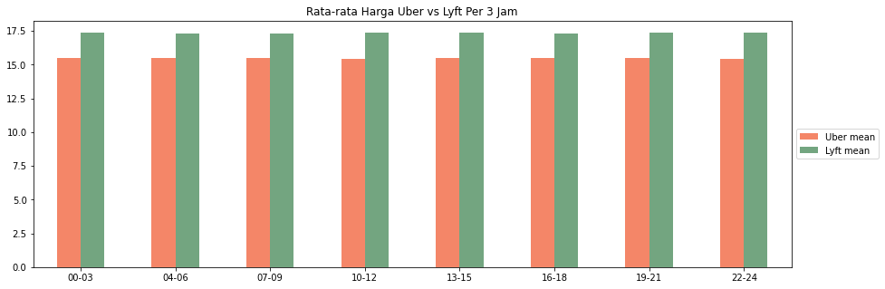

```python
data = {"Uber mean":[dv11['price'].mean(), dv12['price'].mean(), dv13['price'].mean(),
                     dv14['price'].mean(), dv15['price'].mean(), dv16['price'].mean(),
                     dv17['price'].mean(),dv18['price'].mean()],
        "Lyft mean":[dv19['price'].mean(), dv110['price'].mean(), dv111['price'].mean(),
                     dv112['price'].mean(), dv113['price'].mean(), dv114['price'].mean(),
                     dv115['price'].mean(), dv116['price'].mean()]
        };

index = ["00-03", "04-06",'07-09','10-12','13-15','16-18','19-21','22-24'];

dataFrame = pd.DataFrame(data=data, index=index);

dataFrame.plot.bar(rot=0,title="Rata-rata Harga Uber vs Lyft Per 3 Jam", color=['#f48668','#73a580'],figsize=(15,5));
plt.gca().legend(loc='center left', bbox_to_anchor=(1, 0.5))
plt.show(block=True);
```

Berdasarkan visualisasi di atas, dapat disimpulkan bahwa **rata-rata harga Uber maupun Lyft tidak berbeda jauh per 3 jam.** Selain itu, visualisasi di atas juga menunjukkan bahwa **rata-rata harga Lyft cenderung lebih tinggi dibandingkan Uber**